# Introduction to R and R Objects

# Testing and Coercing Objects

From character to complex, and from vector to data frame, you’ve now seen the large majority of R’s data types (modes) and data structures.

Sometimes, it is helpful to test for a certain data type or coerce an object from one type to another. The commands for testing and coercing objects are summarized below (along with the commands to create the objects):

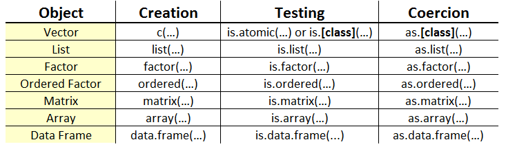

*Figure 1.6: R Commands for Creting, Testing, and Coercing Objects*

**Note** that coercion to a certain data type is not always possible. For example, you can coerce a real number into a character string but you cannot coerce a character string into a numeric/integer value. In general, all data types can be generalized into the *character* type.

# Try it!: Testing and Coercing Objects

What do you expect the result of these expressions to be? Note that we’re using functions to both test for a certain data type or coerce to a certain data type.

```r
# test to see if the days object is a character vector
is.character(days)

# test to see if the profitloss object is a logical vector
is.logical(profitloss)

# coerce the revenues object into a character vector...what's the difference btw input and output?
revenues
as.character(revenues)

# coerce the days vector into a numeric vector...did you expect the result?
as.numeric(days)

# test the following objects in regards to their data structure
is.logical(profitloss)
is.atomic(days)
is.data.frame(findf)

# coerce the following objects into different data structures
as.list(findf)
as.matrix(findf)
```

# Subsetting and Indexing Objects

R has three operators for subsetting objects in the workspace:

- **[**: used to index objects and preserve their structure in the output
- **[[**: used to index object and simplify their structure in the output (e.g. subset a list with output returned as a vector)
- **$** shorthand for using [[ subsetting with a character string (assumes object has been assigned names).

The major difference in the different subsetting operators, is what *type of object* is returned after indexing. We will go through some examples first before covering this in more detail.

With these operators, you can subset a vector using the following:

- **Positive Integers**: will return the elements at the specified positions.
- **Negative Integers**: will omit elements at the specified positions.
- **Logical Vectors**: will select the elements where the corresponding logical value is TRUE.
- **Character Vectors**: will return the elements with matching names (implies names have been assigned to an object’s elements).

**Note** R is atypical from most other programming languages in that it indexs starting from 1 (rather than from 0)!!

# Subsetting: Simplifying vs. Preserving

To keep things straight, here is a nice summary of which operators *simplify* or *preserve* the original data structure of the object being indexed:

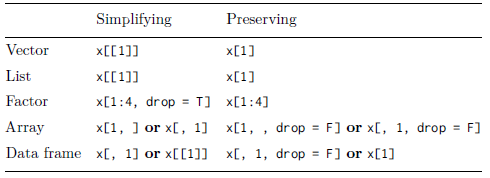

*Fig 1.7: Simplifying vs. Preserving with Subsets!*

*Source: Advanced R (pg. 41-42)*

# Try it!: Subsetting and Indexing Vectors

Here are examples demonstrating several way to index vectors:

```r
# let's refresh ourselves on what the profitloss vector contains
profitloss # we're not using print in this situation, they are equivalent!

# return the first element of the vector with an positive integer index
profitloss[1]

# subset the 2nd and 5th elements using c()
profitloss[c(2, 5)]

# exclude elements of a vector using negative integers
profitloss[-3]

# subset a vector with a logical vector
profitloss[profitflag]
```

# Try it: Subsetting and Indexing Matrices

Here are examples showing ways to index matrices. These concepts generalize to arrays, with the main difference being that arrays have more dimensions available to index.

```r
# view matrix
finmatrix

# return the fourth row of the matrix....ROW IS THE FIRST ARGUMENT
finmatrix[4, ]
finmatrix[4, , drop = FALSE]

# return just the second column of finmatrix...COLUMN IS THE SECOND ARGUMENT after a ,
finmatrix[,2]

finmatrix[, 2, drop = FALSE] # setting drop = FALSE preserves the matrix object

# return the element found in the 3rd row, 2nd column of the matrix
finmatrix[3,2]

# return the 8th element of the matrix (col major order)
finances[8]
```

**Note** these concepts generalize to **arrays** (since matrices are a special case of arrays). The main difference being, in the case of arrays, you’ll have more *dimensions* to potentially subset.

# Try it!: Subsetting and Indexing Data Frames

Indexing data frames is very similar to indexing matrices, as both are 2-dimensional objects composed of rows and colums:

```r
# view findf
findf

# return a subset including the last column...as a vector!
findf[,5]

# return the last column again... but as a data frame!
findf[5]

# return the fourth row of findf
findf[4,]

# return the value in the cell located at the first row and third column
findf[1, 3] # what sort of object does this appear to be

# what do you think the output of this index will be?
findf[1, 3, drop = FALSE]

# similar to other objets, you can index both by name and using the $ shorthand
findf$days
findf["days"]

# subset a data frame using a logical vector
findf[profitflag, , drop = FALSE]
```

# Try it!: Subsetting and Indexing Lists

```r
# print finlist
finlist

# print the first component of the list as a list
finlist[1]
class(finlist[1])

# print the first component of the list as a vector
finlist[[1]]
class(finlist[[1]])

# print the second component of the list by name, notice the difference in output!
finlist["revenues"]
finlist[["revenues"]]

# lists can be indexed either by number or by name, making this code below equivalent to the one before it
finlist$revenues

# you can index the "parent" element of a list to access any "children" elements
# both lines evaluate to prints second element of the "revenues" list component
finlist[["revenues"]][2]
finlist$revenues[2]
```

# The Working Directory and R Environments

Each R session has a *working directory* which is the specific file path R uses to search for files and/or write files, among other things.

- **getwd()**: returns the current session’s working directory (typically a folder on your computer)
- **setwd()**: takes in a character string, which is the file path you wish to use for a working directory
- **dir.exists()**: checks to see if a folder exists in the current directory, or specified path. Returns TRUE or FALSE
- **dir.create()**: can be used to create a new folder on your computer
- **file.exists()**: checks to see if a file exists in the current directory, or specified path. Returns TRUE or FALSE
- **file.create()**: can be used to create a new file path on your computer
- **dir()** or **list.files()**: returns all files that exist in the working diretory

Each time you use R, there is also an *environment* during each session (actually, there many environments that are nested within each other). These environments are what R searches within to find variables, functions, etc.

- **ls()**: lists all the objects in the current environment
- **rm()** or **remove()**: remove one or more objects from current environment; **rm(list=ls())** will remove *all* objects
- **search()**: list of attached environments in the current session
  - *Environments* have a parent-child relationship, where each enviroment keeps track of its parent but are unaware of which environments are its children. These environments (i.e. the *Global Environment*, packages you load during a session), are what R searches through one-by-one until it finds the object or function used in an expression.

# Help with R

If you ever find yourself wanting more information surrounding objects, fucntions, data structures, packages, or anaything else, try these resources:

- **help() or ?**: search a function name or topic
- **help.start()**: similar to help() but starts an HTML version of R’s documentation
- **??**: a more robust search of the documentation, uses fuzzy matching
- [CRAN](https://cran.r-project.org/)
- [R Tag on Stack Overflow](https://stackoverflow.com/)
- [R Mailing Lists](https://www.r-project.org/mail.html)

# Additional Resources

- *Introduction to R* by Venables, Smith, and the R Core Team
- *R for Beginners* by Emmanuel Paradis
- [TryR](http://tryr.codeschool.com/) is a free online introduction to R sponsored by O’Reilly
- Use the **swirl package** to reinforce the concepts presented today, and better understand R’s behavior. This package is an interactive teaching tool, providing both instruction and practice exercises. Install and load the swirl package, and then enter **swirl()** into the console to begin the interactive tutorials
- In addition to the common operators, R also contains facilities for performing matrix operations especially in the context of linear algebra. Start with [Quick-R’s page on Matrix Algebra](http://www.statmethods.net/advstats/matrix.html) if you want to learn more